# MSDS 7333 Case Study 06

Matthew Baldree, Ben Brock, Tom Elkins, Austin Kelly

June 17, 2017

### Table of Contents:

Assignment Requirements

Introduction

**Part 1**

- Signal Collection
- Signal Strength
- Signal Density
- Discussion
- k-Nearest Neighbors

**Part 2**

- 2.1 Examining Power
- 2.2 Examining Weights
- 2.3 Weighted kNN
- Future Study

References

Appendix

### **Assignment**

1. Conduct a more thorough data analysis into these two MAC addresses, including determining locations by using data corresponding to both the *chosen* and *rejected* Access Points:
   - *Which of these two MAC addresses should be used and which should not be used for Real Time Location System (RTLS)?*
   - *Which MAC address yields the best prediction of location? (Including determining locations by using data corresponding to both MAC addresses)?*
   - *Does using data for both MAC addresses simultaneously yield more, or less accurate prediction of location?*
2. Implement alternative k-nearest neighbors prediction method using weights on received signal strength.
   - *For what range of values of weights are you able to obtain better prediction values than for the unweighted approach?*
   - *Use calcError() to compare approaches.*

↑TOC

### **Introduction**

#### *Explain the case study*

The case study in chapter 1 of the book *Data Science in R* by Nolan and Lang presented an indoor posiitoning system (IPS) for WiFi devices on a floor of a building at the University of Mannheim. The IPS was trained and tested with data collected at the University with a hand-held device on a grid of 166 points spaced one meter apart in the hallways. The algorithm for the IPS is the K-Nearest Neighbors (k-NN) [1].

The original investigators used a hand-held scanning device at each point and recorded a timestamp, MAC id of the device, position of the device, the orientation of the device, and the following data for each WiFi access point (AP): recevied signal strength, channel frequency, and device mode of operation. The WiFi APs were located throughout the building and identified by their unique Media Access Control (MAC) address.

This is an example of the training input:

t=1139643118358;id=00:02:2D:21:0F:33; pos=0.0,0.0,0.0; degree=0.0; 00:14:bf:b1:97:8a=-38,2437000000,3; 00:14:bf:b1:97:90=-56,2427000000,3; 00:0f:a3:39:e1:c0=-53,2462000000,3; 00:14:bf:b1:97:8d=-65,2442000000,3; 00:14:bf:b1:97:81=-65,2422000000,3; 00:14:bf:3b:c7:c6=-66,2432000000,3; 00:0f:a3:39:dd:cd=-75,2412000000,3; 00:0f:a3:39:e0:4b=-78,2462000000,3; 00:0f:a3:39:e2:10=-87,2437000000,3; 02:64:fb:68:52:e6=-88,2447000000,1; 02:00:42:55:31:00=-84,2457000000,1

| Data Element | Description | Type | Example |
| --- | --- | --- | --- |
| t | timestamp (milliseconds since midnight 1/1/1970) | long integer | t=1139643118358 –> 2/11/2006 07:35:28 |
| id | target device MAC address | 6-octet sequence in hexadecimal | id=00:02:2D:21:0F:33 |
| pos | coordinates of the target device in meters from a choke point in the host building | 3 floating point values, comma-separated | pos=0.0,0.0,0.0 |
| degree | Orientation of the target device (with respect to North) in degrees | float | degree=0.0 |
| MAC Address | one or more reports from various Access Points | comma-separated value list | 00:14:bf:b1:97:8a=-38,2437000000,3 |

`Table 1 - Data Element Description for the training data`

| Data Element | Description | Type | Example |
| --- | --- | --- | --- |
| signal | The signal strength reported for the Access Point in dBm | integer | -38 |
| channel | The frequency of the channel used by the Access Point in Hz | integer | 2437000000 |
| mode | The mode of operation for the Access Point (1 = Ad Hoc, 3 = Access Point) | integer | 3 |

`Table 2 - Data Element Description for the Access Point measurements`

Six APs were initially discovered in the original analysis in the case study. The authors then decided to reject AP “00:0f:a3:39:dd:cd” (rejectedAP) stating it was identified as an extra address. The details of their reasoning was not clearly explained. The authors chose AP “00:0f:a3:39:e1:c0” (chosenAP) instead. This case study will evalute the author’s decision and decide if the IPS would be more accurate with the chosenAP, rejectedAP, or both APs.

The k-NN algorithm is an ideal method because we have an abundant training data set and our prediction is not based on parametric relationship with the data. It is based on proximity. The downside is the model must hold the entire training data set in memory for maximum predictability. The k-NN model is trained on the training data and then tested on the test data to determine its accuracy. The number of neighbors to be used for location prediction is adjusted to improve the accuracy.

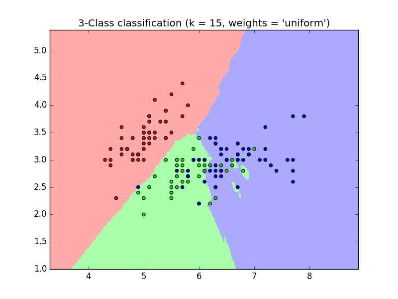

Figure 1 - An example of k-Nearest Neighbors from scikit-learn [2]

In part 1 of the case study, the author’s original decision to reject an AP is revisited to see if this was the best decision. In part 2, the prediction of X,Y based on the average of it’s neighbors is revisited and modified to a weighted sum of X,Y to determine if this change will produce better predictions. Alternate weights will also be analyzed.

↑TOC

# Part 1: Access Point Analysis

The majority of the code in this case study was leveraged from [1]. The code was refactored for readibility and modified for part 1 and 2 analysis.

## 1.1 Read and Clean the Data

Set options parameters for printing and formatting.

```r
options(digits = 2)
options(error = recover, warn = 1)
```

Include helper functions defined in another notebook.

```r
source("MSDS7333-baldree-case6-fx.r", print.eval = TRUE)
```

Read in offline data used for training our model.

```r
offline = readData()
```

## 1.2 Analyze the Two Acess Points

Define the access point (AP) MAC addresses that will be analyzed. We also define a variable for all remaining APs.

```r
chosenAP = "00:0f:a3:39:e1:c0"
rejectedAP = "00:0f:a3:39:dd:cd"
remainingAP = unique(offline[!offline$mac %in% c(chosenAP, rejectedAP),]$mac)
```

↑TOC

### 1.2.1 Signal Map

Plot the total signals captured for each AP to determine if the coverage was similar. A severe gap in the number of points captured could be a reason for lower predictability.

The total signals for each AP MAC in question, chosenAP and rejectedAP, are plotted at their respective X,Y point. We are unable to plot the access points (APs) directly on the map because we do not know their X, Y coordinates.

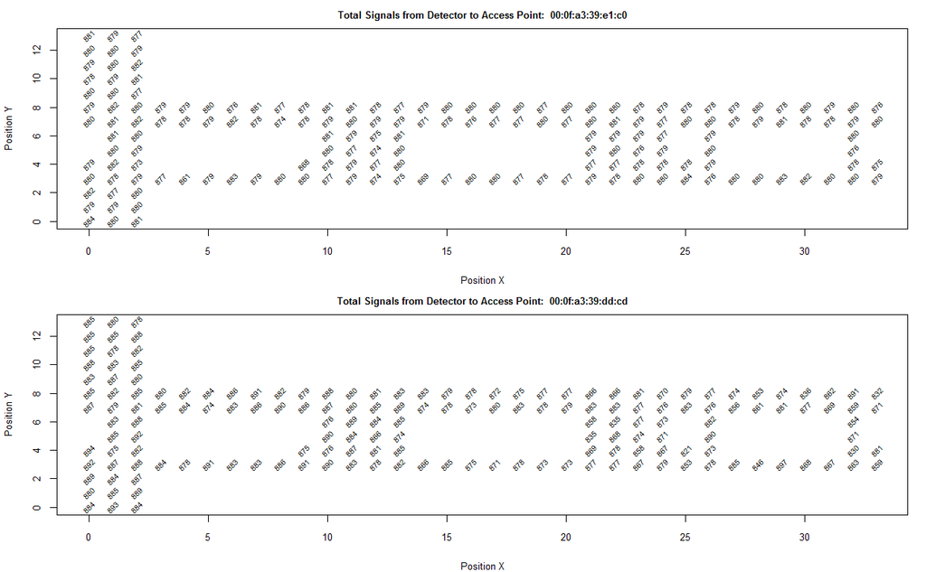

```r
plotSignalMaps(c(chosenAP, rejectedAP))
```

```r
#  Figure 2 - Number of reports at each location for the rejected and chosen APs.
```

The maps show there were near equal amounts of training points captured for both APs. A visual comparison of these two diagrams does not give us sufficient insight into which MAC address should be kept and which should be rejected. Now, let us examine the distribution strength of the APs.

↑TOC

### 1.2.1 Signal Strength Distributions

Plot the signal strength distributions for each AP per angle for better understanding at location (X=2, Y=12). A more thorough analysis would examine the distributions at all locations points, but time did not permit this in-depth analysis. Instead, we will later create a summary statistic to analyze.

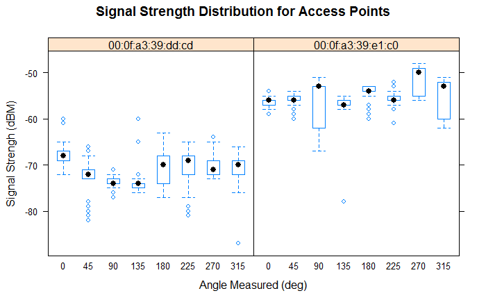

```r
df = subset(offline, posX ==2 & posY == 12 & !(mac %in% remainingAP), c(signal, angle, mac))
plotBoxplotSignalStrength(df)
```

```r
# Figure 3 - Signal strength distribution across both Access Points
```

The higher the decibel-milliwatts (dBm) means a stronger signal strength which indicates a closer physical position to the AP since signal strength decreases exponentially with distance. The distribution shows AP “e1:c0” has a stronger signal strength at this location than “dd:cd.” But, the two of them together cover a wider range of signal coverage. What would this plot look like if we moved the fixed location point on the other side of the building at (X=33, Y=3)?

Next, we plot the signal strength distributions for each AP per angle for better understanding at location (X=33, Y=3).

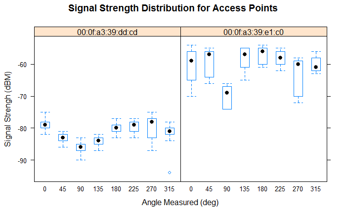

```r
# Let's focus on the fixed point (33,3)
df = subset(offline, posX == 33 & posY == 3 & !(mac %in% remainingAP), c(signal, angle, mac))
plotBoxplotSignalStrength(df)
```

```r
# Figure 4 - Signal strength distribution for a point at the other end of the building
```

This plot is similar to the previous distribution but with one outlier. At this point we know signal strength is different for the two access points. We do not know if this will affect our prediction accuracy. Now, let us analyze the two AP’s signal strength distribution over angles.

↑TOC

### 1.2.2 Signal Density

Plot signal strength frequency per capture angle for normalcy.

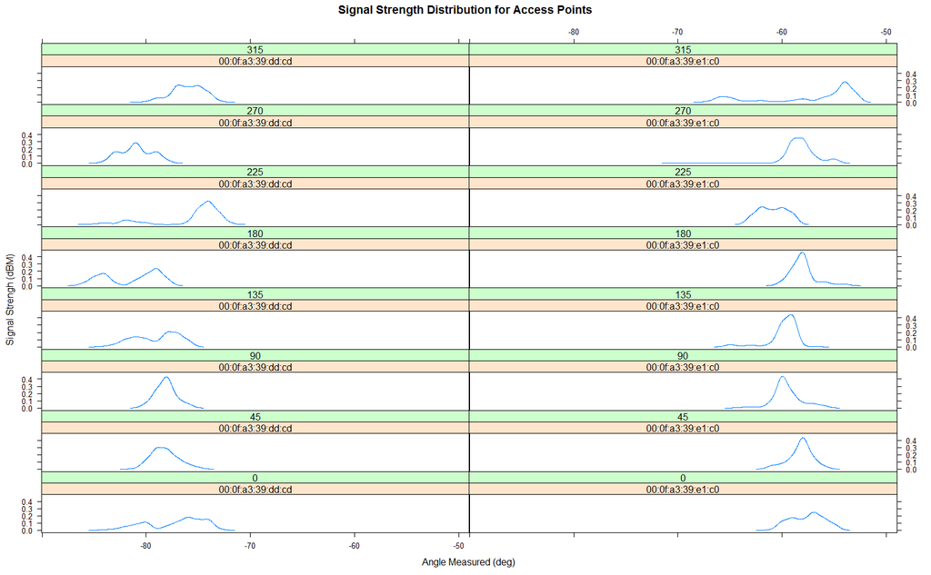

```r
df = subset(offline, posX == 24 & posY == 4 & !(mac %in% remainingAP), c(signal, angle, mac))
plotDensitySignalStrength(df)
```

```r
# Figure 5 - Signal strength distribution across angles
```

The above plot shows the rejectedAP “dd:cd” has a higher signal density at lower strength while the acceptedAP “e1:c0” has a higher density coverage at a higher strength. The distributions show many of the plots are normally distributed while some of them, (e.g., “dd:cd” at 180 and “e1:c0” at 315) are heavily skewed or even bimodal. Looking at each AP from top to bottom, there seems to exist an obvious pattern with respect to angle. This would suggest the median of each distribution varies by angle which can be attributed to a difference in perceived strength. This means the angle of the device contributes to the APs strength of signal.

#### Average Signal Strength Distributions

Plot the signal strength distribution for all locations through the average signal strength for all locations by angle by creating a summary statistic for all possible locations.

```r
offlineSummary = createOfflineSummary(offline)
```

```r
offline$posXY = paste(offline$posX, offline$posY, sep="-")
# create data frames for each combination
byLocAngleAP = with(offline, by(offline, list(posXY, angle, mac), function(x) x))
```

Now, we calculate the summary statistics:

```r
signalSummary = lapply(byLocAngleAP, function(oneLoc) {
  ans = oneLoc[1, ]
  ans$medSignal = median(oneLoc$signal)
  ans$avgSignal = mean(oneLoc$signal)
  ans$num = length(oneLoc$signal)
  ans$sdSignal = sd(oneLoc$signal)
  ans$iqrSignal = IQR(oneLoc$signal)
  ans
})
offlineSummary = do.call("rbind", signalSummary)
```

The Standard Deviation of the average signal strength per targeted AP:

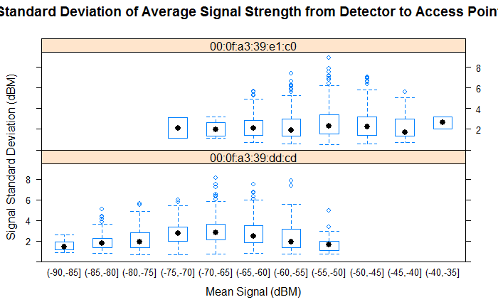

```r
df = subset(offlineSummary, mac %in% c(chosenAP, rejectedAP), c(sdSignal, avgSignal, mac))
plotStdDevSignalStrength(df)
```

```r
# Figure 6 - Standard deviation of average signal strength
```

This above figure shows there is considerable overlap between the two distributions of signal strength. This suggest there may be value in keeping both APs in the k-NN model.

↑TOC

### 1.2.3 Discussion

The data analysis shows that both APs are very similar except for the signal strength coverage. We do not have enough information at this time to determine if one AP is better or worse than the other. Therefore, we will examine each one in the k-NN model along with both of them to determine which option yields the best accuracy.

↑TOC

### 1.2.4 K-Nearest Neighbors

k-NN is a non-parametric machine learning algorithm that is instance-based learning as opposed to generalized learning. Our first implementation of k-NN learns based on the number of neighbors within signal strength distance to the point in question from the training points.[2]

```r
macs = unique(offlineSummary$mac)
macs
```

```
[1] "00:0f:a3:39:dd:cd" "00:0f:a3:39:e1:c0" "00:14:bf:3b:c7:c6" "00:14:bf:b1:97:81"
[5] "00:14:bf:b1:97:8a" "00:14:bf:b1:97:8d" "00:14:bf:b1:97:90"
```

```r
# Table 3 - Unique Access Points
```

Table the test data to review the frequency for each angle and each coordinate.

```r
online = readData("online.final.trace.txt", subMacs = macs)
online$posXY = paste(online$posX, online$posY, sep = "-")
length(unique(online$posXY))
```

```
[1] 60
```

```r
tabonlineXYA = table(online$posXY, online$angle)
#output shows measurements were taken at all angles throughout the floor
tabonlineXYA
```

```
               0  45  90 135 180 225 270 315
  0-0.05       0   0   0 704   0   0   0   0
  0.15-9.42    0   0 717   0   0   0   0   0
  0.31-11.09   0   0   0   0   0 684   0   0
  0.47-8.2   701   0   0   0   0   0   0   0
  0.78-10.94 695   0   0   0   0   0   0   0
  0.93-11.69   0   0   0   0 691   0   0   0
  1.08-12.19   0   0   0   0   0 742   0   0
  1.24-3.93    0   0   0   0   0   0 683   0
  1.39-6.61    0   0   0 706   0   0   0   0
  1.52-9.32  690   0   0   0   0   0   0   0
  1.55-0.96    0   0   0   0   0   0   0 691
  1.58-5.26    0   0   0   0 695   0   0   0
  1.71-1.81    0   0 696   0   0   0   0   0
  1.86-8.08    0   0   0 694   0   0   0   0
  10.23-6.88   0   0   0   0   0 694   0   0
  10.46-5.8    0 671   0   0   0   0   0   0
  10.62-3.87   0 701   0   0   0   0   0   0
  10.99-7.19   0   0   0   0   0   0 691   0
  11.39-5      0   0 690   0   0   0   0   0
  11.76-7.76   0   0   0   0 716   0   0   0
  12.16-5.25   0   0 683   0   0   0   0   0
  12.18-3.4    0   0   0   0   0   0 678   0
  12.26-6.72   0   0 692   0   0   0   0   0
  12.55-7.38 683   0   0   0   0   0   0   0
  12.95-5.25   0   0   0 707   0   0   0   0
  14.98-7.55   0   0 695   0   0   0   0   0
  16.44-7.45   0   0   0   0   0   0 669   0
  2.02-7.45    0   0 693   0   0   0   0   0
  2.49-7.6     0   0   0   0   0   0   0 701
  21.23-5.47   0   0   0 689   0   0   0   0
  21.3-3.8     0   0   0 703   0   0   0   0
  21.45-6.62   0 646   0   0   0   0   0   0
  21.6-7.63    0   0   0   0 669   0   0   0
  21.98-7.46   0   0   0   0   0   0   0 692
  22.3-6.36    0   0   0 666   0   0   0   0
  22.38-3.94   0   0   0   0   0   0   0 649
  22.76-5.06   0   0   0   0   0   0 684   0
  23.24-7.5  685   0   0   0   0   0   0   0
  23.36-3.4    0   0   0   0   0   0   0 689
  23.53-4.22   0   0   0   0   0 646   0   0
  23.9-7     667   0   0   0   0   0   0   0
  24.31-3.89   0   0   0   0   0   0   0 697
  24.7-7.7     0   0 679   0   0   0   0   0
  25.23-7.78 698   0   0   0   0   0   0   0
  25.76-7.34   0   0   0 692   0   0   0   0
  26.71-7.5    0   0 674   0   0   0   0   0
  28.12-7.57   0   0   0   0   0   0   0 704
  29.58-7.93   0   0   0   0   0   0   0 697
  3.44-7.43    0 691   0   0   0   0   0   0
  31.06-7.19   0   0   0   0   0 654   0   0
  31.78-7.62   0   0   0   0   0   0 722   0
  32.16-7.08   0   0 745   0   0   0   0   0
  32.54-7.08   0 678   0   0   0   0   0   0
  4.51-7.63    0   0   0   0   0   0   0 728
  6-7.88       0   0   0 661   0   0   0   0
  7.48-7.36  701   0   0   0   0   0   0   0
  8.56-7.64    0   0   0   0   0   0   0 684
  9.08-7.24  663   0   0   0   0   0   0   0
  9.46-7.77    0   0   0   0 690   0   0   0
  9.86-3.88    0   0   0   0 680   0   0   0
```

```r
# Table 4 - Test data counts per location and angle
```

The above output shows that each angle has test data meaning we can test all angles for accuracy.

Let’s Reshape the test data where each AP is in a column.

```r
onlineSummary = castOnline(online)
#confirm rejected AP is included
dim(onlineSummary)
```

```
[1] 60 12
```

```r
names(onlineSummary)
```

```
 [1] "posXY"             "posX"              "posY"              "orientation"
 [5] "angle"             "00:0f:a3:39:dd:cd" "00:0f:a3:39:e1:c0" "00:14:bf:3b:c7:c6"
 [9] "00:14:bf:b1:97:81" "00:14:bf:b1:97:8a" "00:14:bf:b1:97:8d" "00:14:bf:b1:97:90"
```

```r
# Table 5 - Reshaped test data set
```

When it comes to the kNN, we need to include the data which include the angles close to the point in question. As observed before, angle matters. For this exercise, we need to abide by the following rules:

- If one angle is desired, then we will include angles which match the rounded orientation of the new observation
- If we want two angles, two multiples of 45 degrees will be chosen in order to encapsulate the new observation’s orientation
- For three angles, the nearest 45 degree increment is chosen and either side will be used.

Now, we analyze our three scenarios for both APs included, rejectedAP left out, and then chosenAP left out. Three neighbors were used for three angles. The accuracy for each scenario as determined by the sum of squares difference between estimated X,Y and actual X,Y were output as well. Cross-validation was not used at this time.

```r
for (ap in c("None", rejectedAP, chosenAP)){
  if (ap == "None"){
    test = onlineSummary
    train = offlineSummary
    newSignals = test[ , 6:12]
  } else {
    test = onlineSummary[, !(names(onlineSummary) %in% ap)]
    train = subset(offlineSummary, mac != ap)
    newSignals = test[,6:11]
  }

  estXY = predXY(newSignals = newSignals,
                 newAngles = test[, 4],
                 train,
                 numAngles = 3, k = 3)
  actXY = test[ , c("posX", "posY")]
  err = calcError(estXY, actXY)

  print(paste(ap, err))
}
```

```
[1] "None 249.426966666667"
[1] "00:0f:a3:39:dd:cd 306.702522222222"
[1] "00:0f:a3:39:e1:c0 270.458077777778"
```

```r
# Table 6 - Accuracies for the various scenarios
```

Our null hypothesis is that all scenarios yield the same error. Our alternative hypothesis is that at least one scenario yields a different error from the others.

- Ho: None Error = ChosenAP Error = RejectedAP Error
- Ha: At least one scenario is different.

The next step is test our hypothesis with an ANOVA test. This step is left for future work. Therefore, we cannot reject Ho at this time.

We will proceed with our analysis with both APs and perform a cross-validation to determine the best k. Three angles were used. Future work would include parameterization of the angles from 1 to 3 to determine the best m.

#### Cross-Validation

Choose a v-fold of 11.

```r
v = 11
```

```r
# number of locations
permuteLocs = sample(unique(offlineSummary$posXY))
```

```r
# matrix locations into folds
permuteLocs = matrix(permuteLocs, ncol = v, nrow = floor(length(permuteLocs)/v))
```

```
data length [166] is not a sub-multiple or multiple of the number of rows [15]
```

```r
# summarize and format offline
keepVars = c("posXY", "posX", "posY", "orientation", "angle")
onlineCVSummary = reshapeSS(offline, keepVars = keepVars, sampleAngle = TRUE)
```

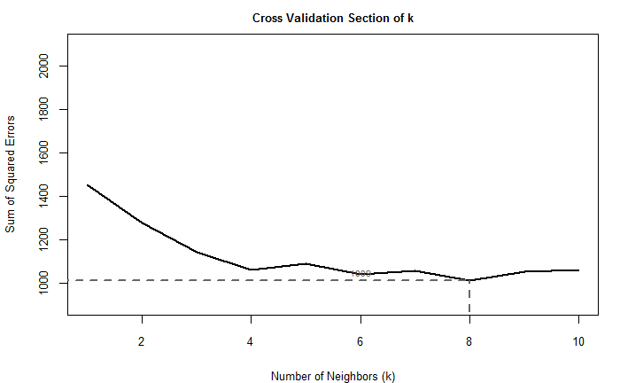

```r
# number of k's
K = 10
# errors array
err = rep(0, K)
# loop through folds
for (j in 1:v) {
  testFold = subset(onlineCVSummary, posXY %in% permuteLocs[ , j])
  trainFold = subset(offlineSummary, posXY %in% permuteLocs[ , -j])
  actFold = testFold[ , c("posX", "posY")]
  # loop through neighbors
  for (k in 1:K) {
    estFold = predXY(newSignals = testFold[ , 6:12],
                     newAngles = testFold[ , 4],
                     trainFold, numAngles = 3, k = k)
    err[k] = err[k] + calcError(estFold, actFold)
  }
}
# plot k to sum of squared errors
plotSSErrors(err, K)
```

```r
# Figure 7 - Estimated ideal 'k'
```

```r
# experiment with a few k's based on above analysis to determine k
# that results in lowest sum squared error on test data.
estXY = predXY(newSignals = onlineSummary[ , 6:12],
               newAngles = onlineSummary[ , 4],
               offlineSummary, numAngles = 3, k = 5)
actXY = onlineSummary[ , c("posX", "posY")]
calcError(estXY, actXY)
```

```
[1] 210
```

Our analysis of three scenarios that included both ChosenAP and RejectedAP and each exclused showed that there might be a potential gain from including both APs. Indeed the accuracy results showed including both APs yielded lower errors. However, this difference in errors was not analyzed for significance and was left for future work. A cross-validation for both APs scenario was performed to find optimal k. Analysis for optimal angle, m, was not peformed and left for future work.

↑TOC

# Part 2: Alternative k-Nearest Neighbors

## 2.1: Examination of Power-based search

The case study document mentioned the curvature in the scatterplots of signal strength versus distance, and suggested using a log function to attempt to remove the curve. Since the signal strength data are reported in dBm, they are already the result of a log function: $dBm = 10*log_{10}(power/1 mW)$; therefore, we converted the reported signal strength values back to a power value and examined the effect that had on location prediction. Many of the functions used previously had to be modified to include the power conversion: $power = 10^{(signal/10)}$ and to use the new field in the calculations. Examination of surface plots of power show that the power value tends to isolate the AP more definitively than signal strength because $power \propto 1/distance^2$.

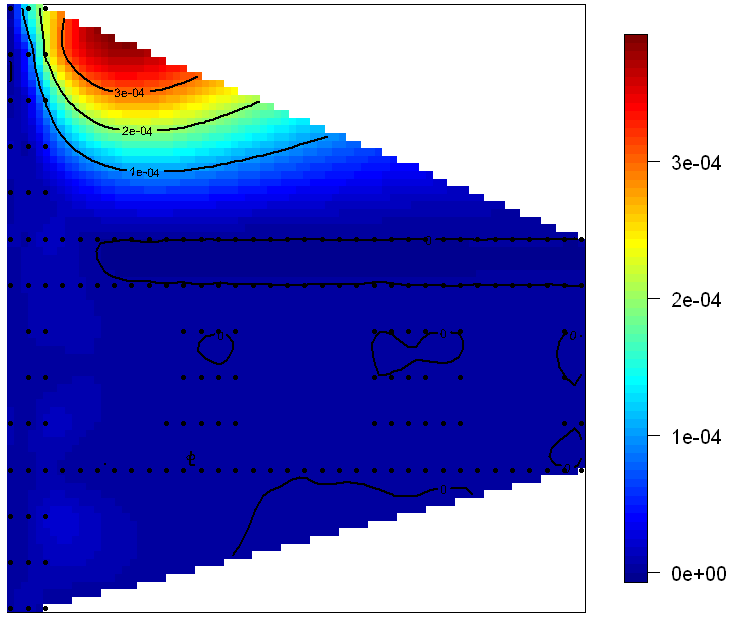

Figure 8 - Contour plot of power for measurements against AP ‘97:8D’ at 0 degrees orientation

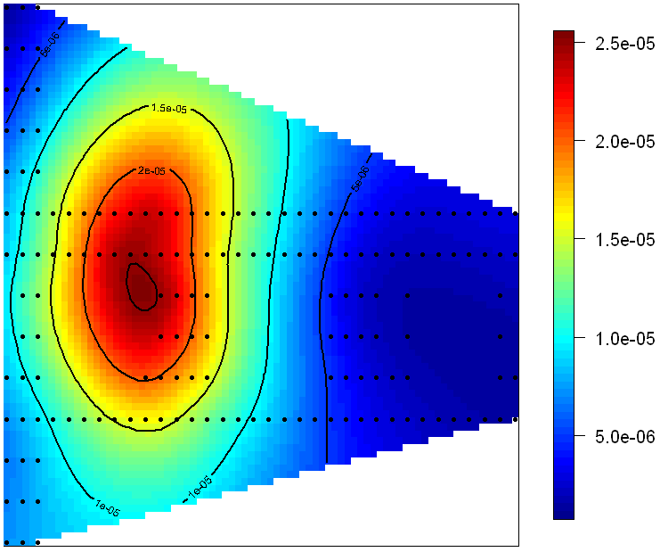

Figure 9 - Contour plot of power for measurements against AP ‘E1:C0’ at 0 degrees orientation

The thought was that by having such a dramatic drop in power over a shorter range, we should be able to reduce the variability in predicted location and get better results. However, when we simply substituted power for signal strength in the existing functions, the predictions using power were worse than using signal strength.

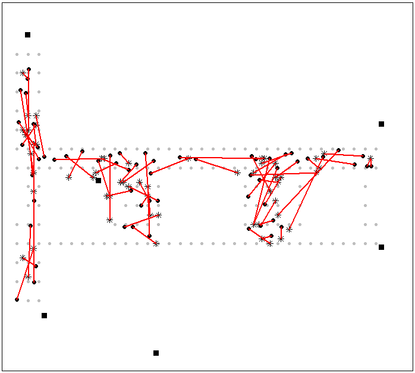

Figure 10 - Red lines indicate distance error between predicted location (*) and true location (black dots) using k=4

Using different values for ‘k’, we had these estimated errors:

| k | Power-based error | Signal-strength-based error |
| --- | --- | --- |
| 1 | 779.8603 | 659 |
| 3 | 598.8870 | 307 |
| 4 | 546.8603 |  |
| 5 | 640.8003 | 276 |

*Table 7 - Comparison of predicted location errors between power-based and signal-strength-based approaches*

Even though the power-based method better isolated the individual APs, we believe that the search algorithm should be redesigned to use all APs, instead of just one or two, due to the power drop-off. As the distance from the reference AP increases, the power drops off so much that it becomes difficult to narrow down the actual location. By redesigning the algorithm to use all APs, we may be able to capitalize on the power drop-off to better hone in on the target’s location.

↑TOC